# Introduction to R

Brendan Holly

1/31/2020

# An Overview

- Using R, R studio and a good R workflow
- The benefits of R
- Basic R actions and data types
- A useful R shortcuts

# R

- R is a free, open-source programming language built on the S language, which was developed by AT&Ts Bell labs in the 1970s.
- R was released in its current form in the 90s
- It’s used primarily for statistics, data analysis, and graphing
- R is a functional programming language

# Why use R?

- Free
- Reproducible
- Considered one of the best graphing programs
- Additional packages provide more functionality than plenty of paid software; often new methods are implemented here first!
- Functionality: create your own functions!

# Understanding R Studio’s layout

Four panes:

1. Source: R scripts
2. Console: Where the scripts are run
3. Enviornment: The area where saved data and variables are stored
4. Files and plots: The area where plots appear and files in the same folder can be viewed

[figure not shown]

# R Scripts

- The record of your work
- Try and keep the script organized. You want to be able to rerun it without errors
- It’s useful to include comments if you’re doing something important or complicated and you want to remember why you did it later

```r
# I'm dropping values greater than 10 because they are outliers

filter(df, x < 10)
```

# Start a New Project

- Every time you start a new class or you’re analyzing new data, make a new R Project!
- R projects are a great way to organize your work
- Put the data files you will use in the same folder as the R project folder

[figure not shown]

# Importing data

- R can handle importing basically any data type!
- Basic format: read(“data_name.csv”)
- Easiest: If the data is in your project folder, import from there!

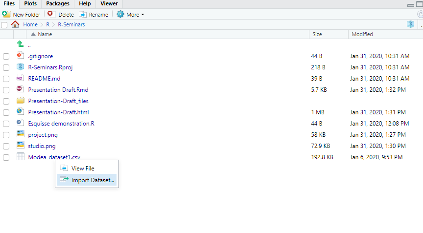

# Best Practice

- Copy the code from this panel and put it at the start of your R script

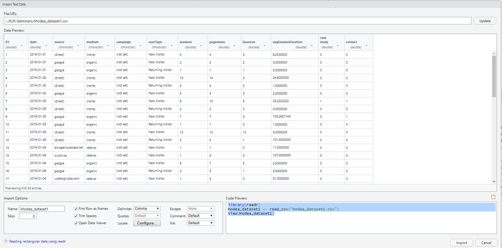

# Examining your data

- str gives an overview of the type of each variable as well as the first couple of rows

```r
data(mtcars)

str(mtcars)
```

```
## 'data.frame':    32 obs. of  11 variables:
##  $ mpg : num  21 21 22.8 21.4 18.7 18.1 14.3 24.4 22.8 19.2 ...
##  $ cyl : num  6 6 4 6 8 6 8 4 4 6 ...
##  $ disp: num  160 160 108 258 360 ...
##  $ hp  : num  110 110 93 110 175 105 245 62 95 123 ...
##  $ drat: num  3.9 3.9 3.85 3.08 3.15 2.76 3.21 3.69 3.92 3.92 ...
##  $ wt  : num  2.62 2.88 2.32 3.21 3.44 ...
##  $ qsec: num  16.5 17 18.6 19.4 17 ...
##  $ vs  : num  0 0 1 1 0 1 0 1 1 1 ...
##  $ am  : num  1 1 1 0 0 0 0 0 0 0 ...
##  $ gear: num  4 4 4 3 3 3 3 4 4 4 ...
##  $ carb: num  4 4 1 1 2 1 4 2 2 4 ...
```

# Examining your data

- View(mtcars) opens up a new window that you can scroll through the data

[figure not shown]

# Assigning a variable name

- Use the assignemnt operator <- to name something
- c is used to combine multiple values

```r
ages <- c(18, 24, 89, 6)
```

# Data types

There are four major data types and most functions require the data is a certain type.

1. Character variables
2. Double variables
3. Logical variables
4. Factors

# Data types

- Character values are surrounded by quotes " "
- You can use is.character to check your variable is the right type

```r
characters <- c("dogs", "cats", "trust")

is.character(characters)
```

```
## [1] TRUE
```

# Double variables

- Numeric variables, which can accept integers or numeric data (with a decimal)

```r
numbers <- c(3, 6, 9, 53)

is.numeric(numbers)
```

```
## [1] TRUE
```

- If you ask if numbers is type character

```r
is.character(numbers)
```

```
## [1] FALSE
```

# Logical variables

```r
logical <- c(TRUE, TRUE, FALSE)

is.logical(logical)
```

```
## [1] TRUE
```

# Factors

- Factors (ordinal variables)

```r
factor <- factor(c("Agree", "Neutral", "Disagree"))

is.factor(factor)
```

```
## [1] TRUE
```

- To see the levels of a factor:

```r
levels(factor)
```

```
## [1] "Agree"    "Disagree" "Neutral"
```

# Mixing data types

- If you data types are mixed, R will choose one

```r
mixed_types <- c(12, 5, 3, "horse")

typeof(mixed_types)
```

```
## [1] "character"
```

# Missing Data

- NA is recorded if there is no data for that observation
- Most functions won’t run if you have NAs in your data
- There are lots of ways to remove NAs, but you want to make sure you understand why they are there in the first place

```r
data <- c(NA, 8, 2, 5)

sum(data)
```

```
## [1] NA
```

```r
data_omit <- na.omit(data)

sum(data_omit)
```

```
## [1] 15
```

# How to name in R

- Shorter is better
- Be descriptive (i.e. don’t name things data or model)
- Don’t include spaces or other weird characters
- I prefer using snake case for variables

```r
# Good (snake case)
trust_values <- c(0, 0, 0)

# Also good (camel case)
trustValues <- c(0, 0, 0)

#Bad
"Trust Values" <- c(0, 0, 0)
```

# Simplest data structures

- A vector is a single variable, with every value of the same type
- Data frames are a group of variables. They can be different types but they must all be the same length!

```r
vector <- c(3, 5, 6)

vector_two <- c("dog", "cat", "mouse")

data_frame <- data.frame(one = vector, two = vector_two)

str(data_frame)
```

```
## 'data.frame':    3 obs. of  2 variables:
##  $ one: num  3 5 6
##  $ two: Factor w/ 3 levels "cat","dog","mouse": 2 1 3
```

# Installing and loading a package

```r
#install.packages("tidyverse")

library(tidyverse)
```

# A graphing shortcut!

- ggplot2 is the premier R graphing package but it can be slightly hard to start out with
- R add-on “esquisse” can be used to make graphs using point and click commands
- Install the package and try it out